# Midpoint Deliverable

### Introductory Paragraph

Sports are one of the many things that help connect people and communities across the globe. We’re interested in making use of this open dataset so people can grow their appreciation and understanding of sports. Providing this kind of data can help improve player performance and encourage fans to attend games.

### Summary Paragraph

The dataset that we ended up using had all sorts of data regarding the Olympics dating as far back from 1896 up to 2016. The dataset was made up of 15 features such as their names, age, height, weight, team, year, etc. Using these features, we were able to find out all sorts of information from the past 120 years of Olympic history. From 1896 to 2016, the Olympic program consisted of 66 events and had 230 teams competing in the Olympics for a medal. We were also able to find out the exact amount of gold medal’s acquired from the teams. Down below, we can see the top 5 countries/team with the most gold medals.

| NOC | gold_medals |
| --- | --- |
| USA | 2638 |
| URS | 1082 |
| GER | 745 |
| GBR | 678 |
| ITA | 575 |

### Table

Some pertinent observations we found inside our aggregated table were…

- United States comes in first place with the most won medals
- Soviet Union comes in second place with half of the United State’s total medals
- Third to tenth place are all in the 1000s with total medals won
- United States almost has 5 times the amount of total medals compared to Hungary

| Team | Total_Medals |
| --- | --- |
| United States | 5219 |
| Soviet Union | 2451 |
| Germany | 1984 |
| Great Britain | 1673 |
| France | 1550 |
| Italy | 1527 |
| Sweden | 1434 |
| Australia | 1306 |
| Canada | 1243 |
| Hungary | 1127 |

### Charts

**Chart 1**

The bar chart shown below answers the question of if age has a relationship with medals earned. It also presents the trend between age and medals earned in the Olympic Games.

This chart specifically reveals that Olympic Athletes in their 20’s earned the most amount of medals, including Bronze, Silver, and Gold individually. It also reveals that Olympic Athletes in their 30’s came 2nd, 10’s came in 3rd, 40’s came in 4th, and 50’s came in 5th. It can be concluded that Olympic Athletes in their 20’s are most likely to earn a medal compared to any other age range.

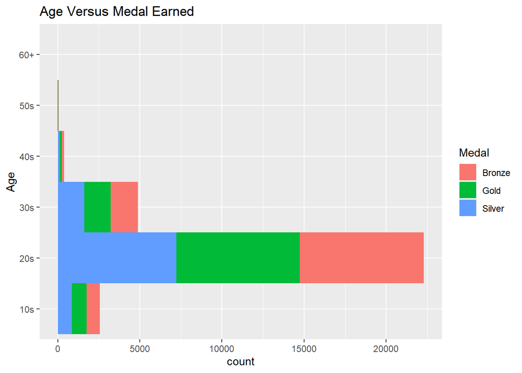

**Chart 2**

This pie chart presents the difference between the amount of medals earned by male athletes and amount of medals earned by female athletes. The “amount of medals” can also be seen individually by Gold, Silver, and Bronze.

This pie chart reveals which sex is most likely to earn more medals in total, as well as individually. Although this may be more specific with sports involved, this pie chart shows that males had more medals in total, as well as in terms of Gold, Silver, and Bronze models compared to females.

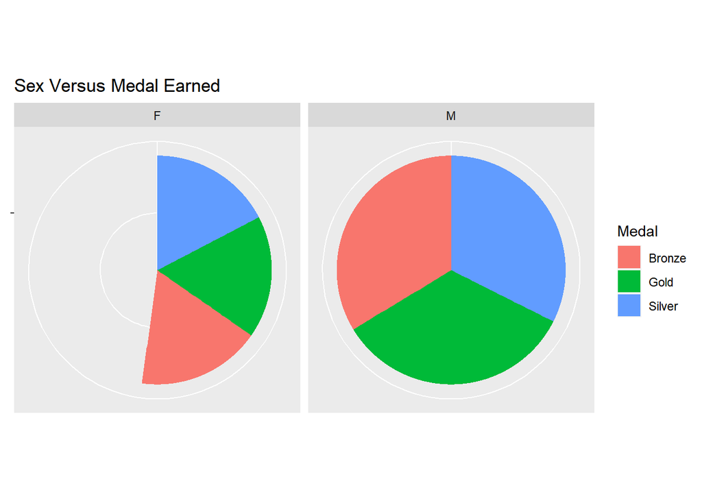

**Chart 3**

This scale plot chart presents the relationship between the Height, Weight, and Age of Olympic Athletes. This chart can easily reveal many things about the data. For example, it reveals that most of the Olympic Athletes are in their 20s. It also reveals the specifics, such as the height of the lightest athlete in weight, the weight of the tallest athlete, the age of some of the athletes in the 50-59kg range, and vice versa. Many more details can be revealed specifically, through this scale plot.

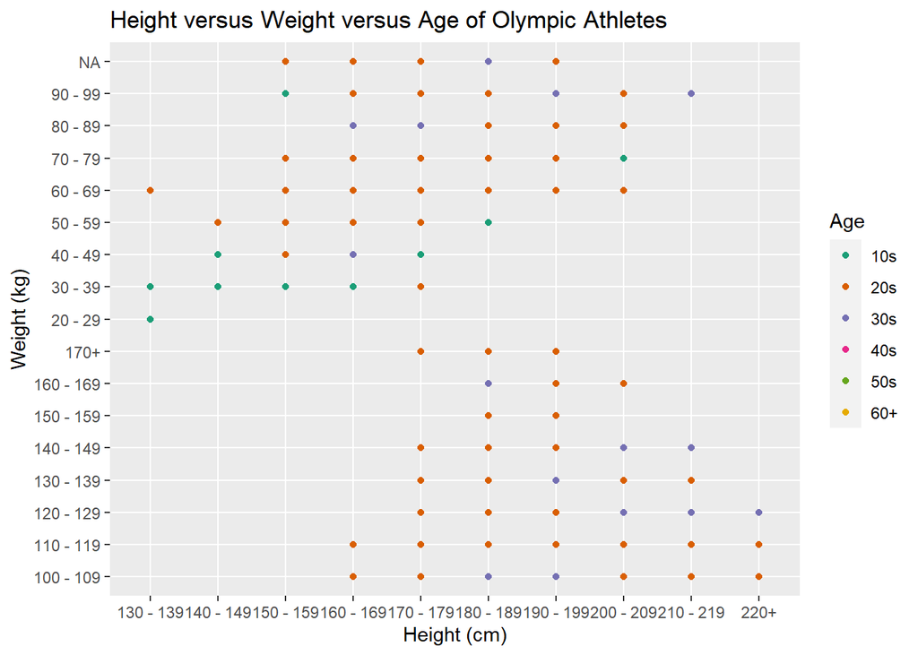